# l7_quant2_ii_en

## Scales

- Intro
- Graph A
- Graph B
- Graph C
- Graph D
- Scales capture values and ranges of each variable to focus the information of interest, taking into account the aesthetics to be plotted:
  - Categories -> colors
  - Numbers -> positions
  - Data range -> graph width
  - etc.
- Scales, in that way, tell us a specific interpretation of the data as continuous, discrete, dates, etc.
- **How they’re named.** Always `scale_<aesthetic>_<type>()`:

| Function | What it’s for |
| --- | --- |
| `scale_x_continuous(limits, breaks, labels)` | Numeric axis: range, marks, and format |
| `scale_x_discrete()` | Category axis |
| `scale_color_manual(values = )` | Choose your own colors |
| `scale_fill_brewer(palette = )` | ColorBrewer palettes |
| `scale_fill_viridis_c()` | Continuous palette, colorblind-friendly |

We fix the axis range with `limits` and the marks with `breaks`.

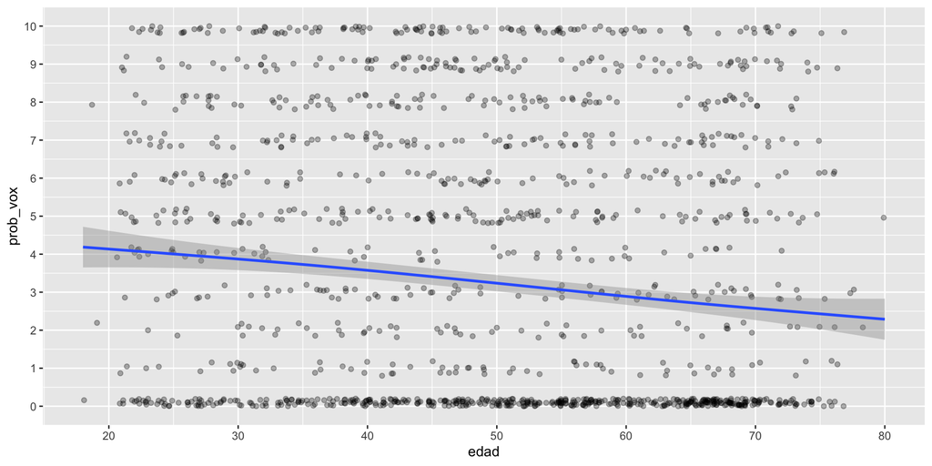

```r
ggplot(data = d, aes(x = edad, y = prob_vox)) +
  geom_jitter(alpha = .3, height = .2) +
  geom_smooth() +
  scale_x_continuous(limits = c(18, 80), breaks = seq(20, 80, 10)) +
  scale_y_continuous(limits = c(0, 10), breaks = 0:10)
```

**Warning**

`limits` **removes** data outside the range (which is why R warns about removed rows) and the trend is recalculated without them. To do only a *zoom*, use `coord_cartesian()`, which we’ll see shortly.

A trend curve **per group**: `color` inside `aes()` separates the lines.

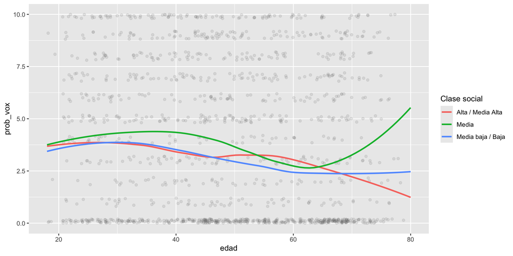

```r
ggplot(data = d, aes(x = edad, y = prob_vox)) +
  geom_jitter(alpha = .15, height = .2, color = "grey50") +
  geom_smooth(aes(color = clase_social), se = FALSE) +
  scale_x_continuous(limits = c(18, 80)) +
  scale_y_continuous(limits = c(0, 10)) +
  labs(color = "Clase social")
```

A heatmap: two categorical variables and the color indicates a percentage. Here, those who worry **a lot or quite a bit** about having to leave their home for economic reasons.

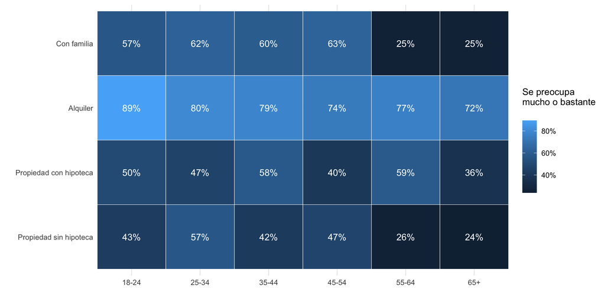

```r
mapa <- d %>%
  filter(!is.na(preocupa_dejar_vivienda), regimen != "Otra situación") %>%
  group_by(edad_r, regimen) %>%
  summarise(pct = mean(preocupa_dejar_vivienda %in% c("Mucho", "Bastante")),
            .groups = "drop")

ggplot(mapa, aes(x = edad_r, y = regimen, fill = pct)) +
  ## geom_tile with white borders
  geom_tile(color = "white") +
  ## write the percentage inside each cell
  geom_text(aes(label = percent(pct, accuracy = 1)), color = "white") +
  ## scales: no margin on x and percentages in the legend
  scale_x_discrete(expand = c(0, 0)) +
  scale_fill_continuous(labels = percent) +
  labs(x = "", y = "", fill = "Se preocupa\nmucho o bastante\n") +
  theme_minimal()
```

**Careful:** some cells have few cases (for example, young people who own their home outright), so their color is not very reliable.

A line per social class with hand-picked colors, a percentage axis, and custom typography.

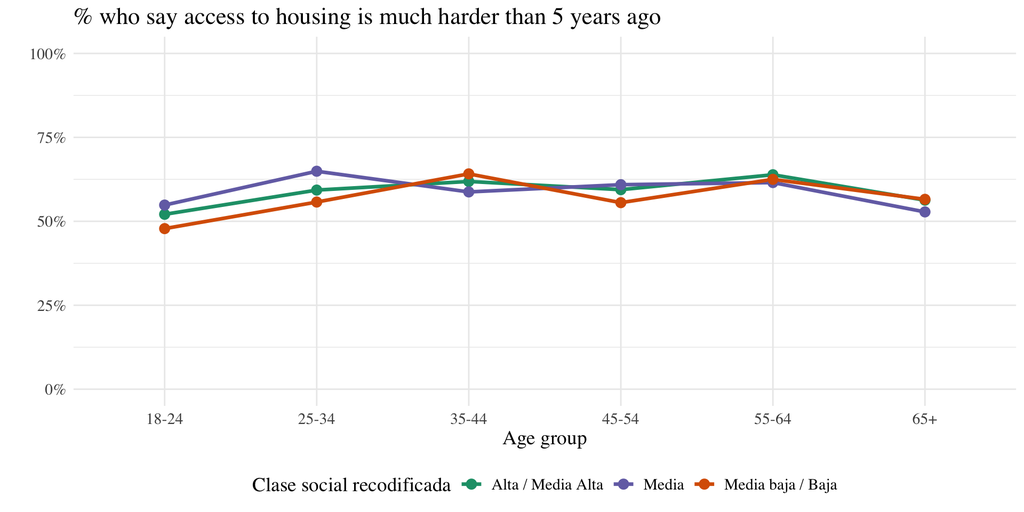

```r
d %>%
  filter(!is.na(acceso_vivienda)) %>%
  group_by(edad_r, clase_social) %>%
  summarise(pct = mean(acceso_vivienda == "Mucho más difícil"), .groups = "drop") %>%
  ggplot(aes(x = edad_r, y = pct, color = clase_social, group = clase_social)) +
  geom_line(linewidth = 1.2) +
  geom_point(size = 3) +
  scale_color_manual(values = c("#1b9e77", "#7570b3", "#d95f02")) +
  scale_y_continuous(labels = percent, limits = c(0, 1)) +
  xlab("Age group") + ylab("") +
  ggtitle("% who say access to housing is much harder than 5 years ago") +
  theme_minimal() +
  theme(text = element_text(size = 14, family = "serif"),
        legend.position = "bottom")
```

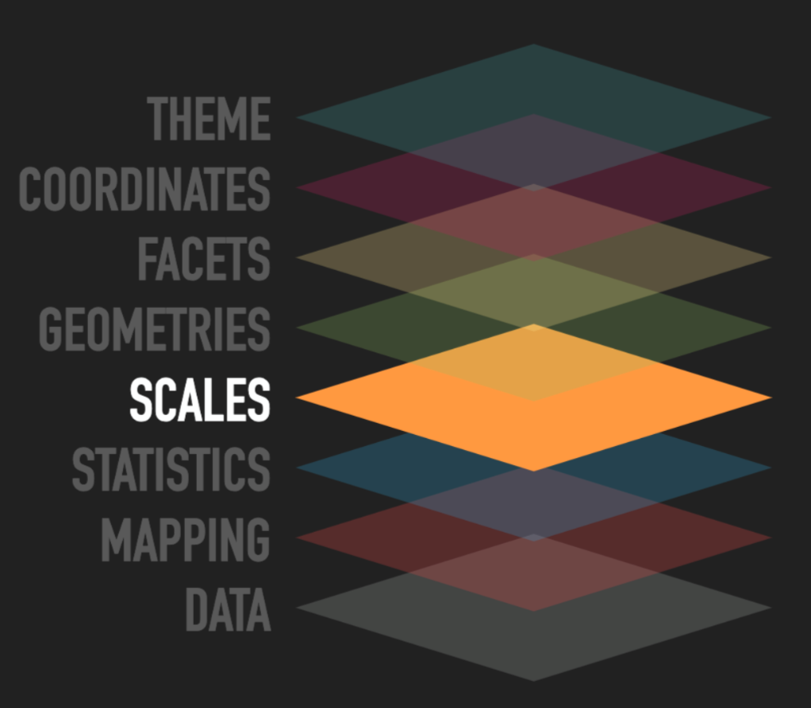

## Coordinates

**Coordinates** are the “canvas” on which everything is drawn. They don’t change the data, only how you see it.

- coord_flip()
- Zoom with coord_cartesian()
- Zoom with limits (careful)

Flips the axes. Useful when category names are long.

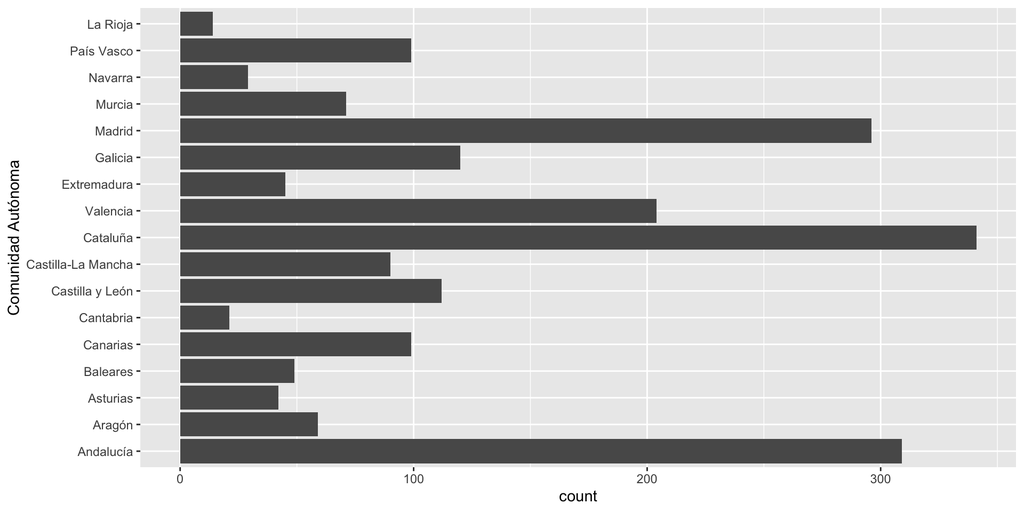

```r
ggplot(d, aes(x = ccaa)) +
  geom_bar() +
  coord_flip()
```

`coord_cartesian()` **zooms in on the image without deleting data**. The trend curve is the same as without zoom.

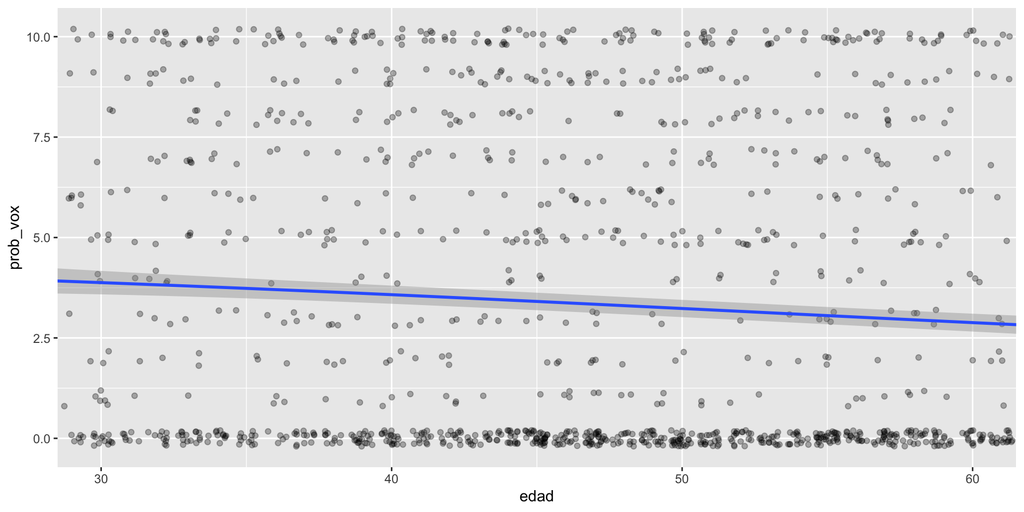

```r
ggplot(d, aes(x = edad, y = prob_vox)) +
  geom_jitter(alpha = .3, height = .2) +
  geom_smooth() +
  coord_cartesian(xlim = c(30, 60))
```

`scale_x_continuous(limits = )` **does delete** the data. The curve is calculated only with what’s left.

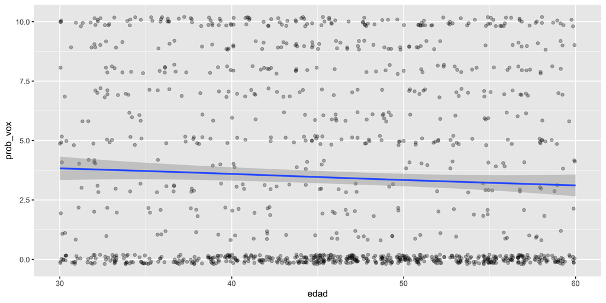

```r
ggplot(d, aes(x = edad, y = prob_vox)) +
  geom_jitter(alpha = .3, height = .2) +
  geom_smooth() +
  scale_x_continuous(limits = c(30, 60))
```

## Facets

- Facets are about splitting the data into sets to plot them separately. They tend to offer an intuitive way to look at subsets of data on their own.
- The final representation also makes more sense by showing all the graphs at once, with **the same axes** so they can be compared.
- `facet_wrap(~ variable)` makes one panel per category and arranges them in rows and columns. `facet_grid(rows ~ columns)` crosses **two** variables.

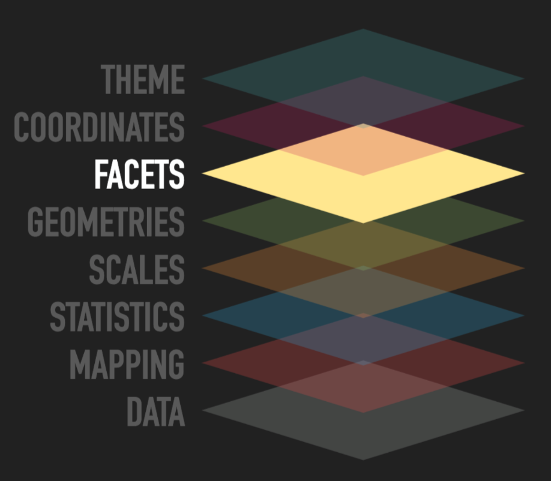

## Facets

- facet_wrap
- facet_grid
- Free axes

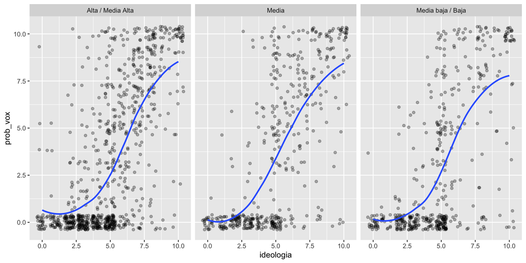

```r
ggplot(data = d, aes(x = ideologia, y = prob_vox)) +
  geom_jitter(alpha = .3) +
  geom_smooth(se = FALSE) +
  facet_wrap(~ clase_social)
```

We cross two variables: sex in the rows and grouped ideology in the columns.

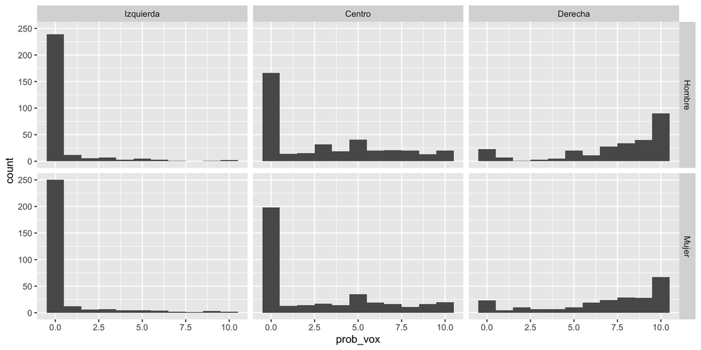

```r
d %>%
  filter(!is.na(ideologia_grupo)) %>%
  ggplot(aes(x = prob_vox)) +
  geom_histogram(binwidth = 1) +
  facet_grid(sexo ~ ideologia_grupo)
```

By default, all panels share axes. `scales = "free_y"` lets each one have its own. Useful, but it **makes comparing harder** (the bars aren’t comparable).

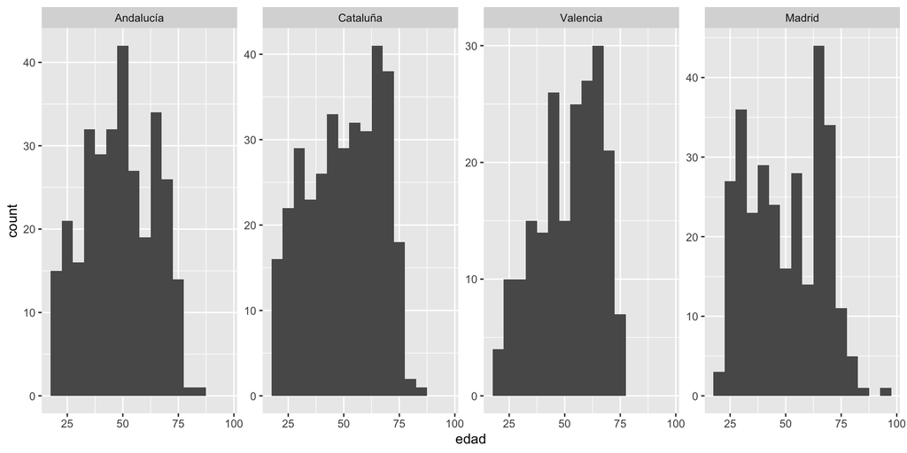

```r
d %>%
  filter(ccaa %in% c("Andalucía", "Cataluña", "Madrid", "Valencia")) %>%
  ggplot(aes(x = edad)) +
  geom_histogram(binwidth = 5) +
  facet_wrap(~ ccaa, nrow = 1, scales = "free_y")
```

## Labels and themes

- Labels: labs()
- Complete themes
- Adjustments with theme()

A graph has to be understood **without anyone explaining it**. `labs()` sets the title, subtitle, axis names, legend, and caption.

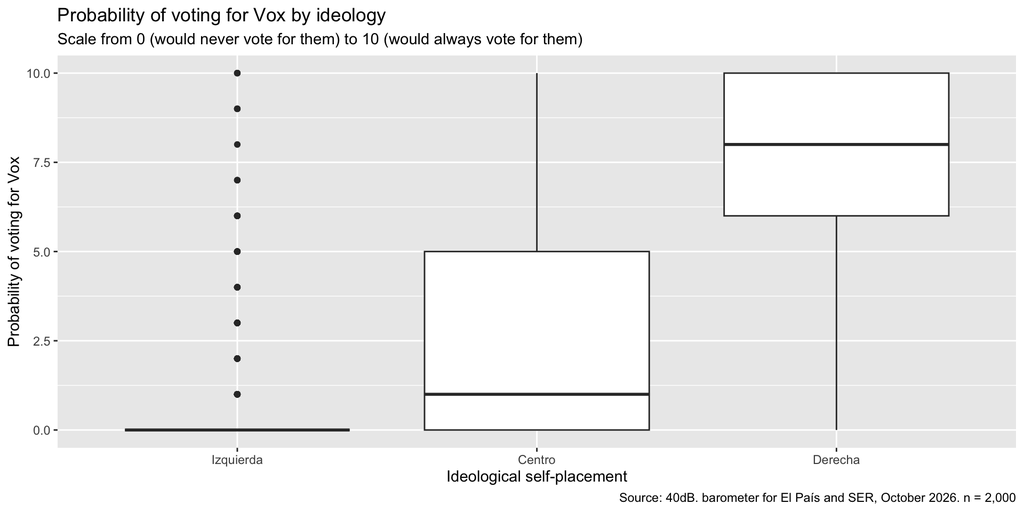

```r
p <- d %>%
  filter(!is.na(ideologia_grupo)) %>%
  ggplot(aes(x = ideologia_grupo, y = prob_vox)) +
  geom_boxplot() +
  labs(title = "Probability of voting for Vox by ideology",
       subtitle = "Scale from 0 (would never vote for them) to 10 (would always vote for them)",
       x = "Ideological self-placement",
       y = "Probability of voting for Vox",
       caption = "Source: 40dB. barometer for El País and SER, October 2026. n = 2,000")
p
```

A theme changes the overall look (background, grid, typography). We save the graph in `p` and add different themes.

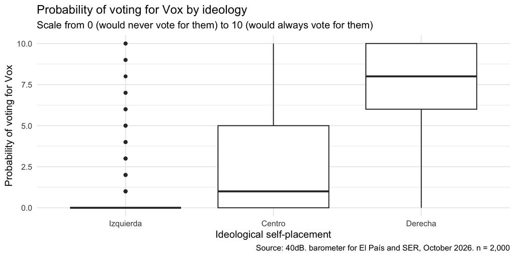

```r
p + theme_minimal(base_size = 14)
```

Also try `theme_bw()`, `theme_classic()`, and `theme_light()`. `base_size` changes the size of all the text.

`theme()` tweaks **specific** elements: legend, tick angle, grid, bold text.

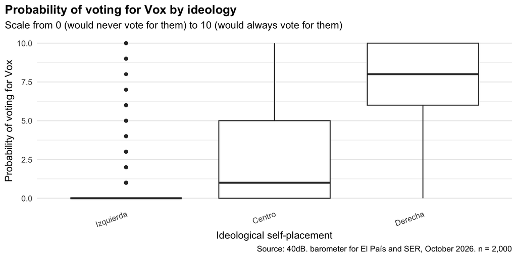

```r
p +
  theme_minimal(base_size = 14) +
  theme(plot.title = element_text(face = "bold"),
        plot.title.position = "plot",
        panel.grid.major.x = element_blank(),
        axis.text.x = element_text(angle = 20, hjust = 1),
        legend.position = "none")
```

## Saving the graph

`ggsave()` saves **the last graph shown** (or whichever you point to with `plot =`). The format is determined by the extension.

```r
grafico <- d %>%
  filter(!is.na(ideologia_grupo)) %>%
  ggplot(aes(x = ideologia_grupo, y = prob_vox)) +
  geom_boxplot()

ggsave("vox_ideologia.png", plot = grafico,
       width = 8, height = 5, dpi = 300)   # for Word or slides
ggsave("vox_ideologia.pdf", plot = grafico,
       width = 8, height = 5)              # vector, for printing
```

- `width` and `height` are in inches by default. Change this with `units = "cm"`.
- The file appears in the **working folder** (`getwd()`).
- A screen looks fine at 150 dpi. For printing, use 300.

## Full recipe: from data to a presentable graph

Question: **what percentage strongly or somewhat agrees with each housing measure?** (`p22_1` to `p22_12`).

- 1. Prepare the data
- 2. First graph
- 3. Final graph

Each measure is a column. To graph it we need **one row per measure**: `pivot_longer()`. Then we calculate the percentage using the weighting.

```r
acuerdo <- d %>%
  select(id, ponde, starts_with("p22_")) %>%
  pivot_longer(starts_with("p22_"), names_to = "item", values_to = "respuesta") %>%
  filter(!is.na(respuesta)) %>%
  mutate(politica = unname(etiq_p22[item])) %>%
  group_by(politica) %>%
  summarise(pct = weighted.mean(respuesta %in% c("Muy de acuerdo", "Bastante de acuerdo"),
                                w = ponde))

acuerdo
```

```
# A tibble: 12 × 2
   politica                                          pct
   <chr>                                           <dbl>
 1 Ban evictions of vulnerable people              0.697
 2 Ban tourist apartments in residential buildings 0.730
 3 Cap on annual rent increases                    0.775
 4 Expand social housing                           0.863
 5 Limit on number of properties per owner         0.521
 6 Monthly rental vouchers                         0.683
 7 Non-payment insurance and legal assistance      0.806
 8 Postpone evictions of vulnerable people         0.780
 9 Public construction of private housing          0.836
10 Raise property tax (IBI) on empty homes         0.541
11 Regulate rental prices                          0.757
12 Tax advantages for small landlords              0.846
```

It works, but it’s messy and has no percentages.

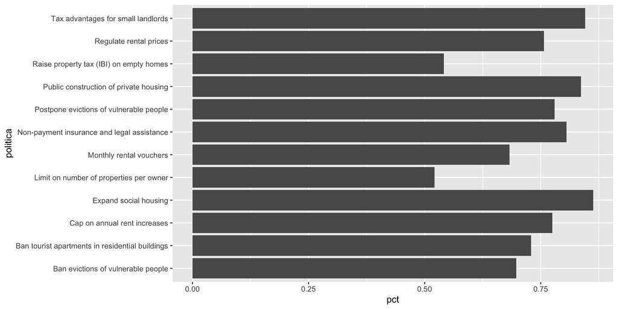

```r
ggplot(acuerdo, aes(x = pct, y = politica)) +
  geom_col()
```

We sort it, add labels, percentage format, and a clean theme.

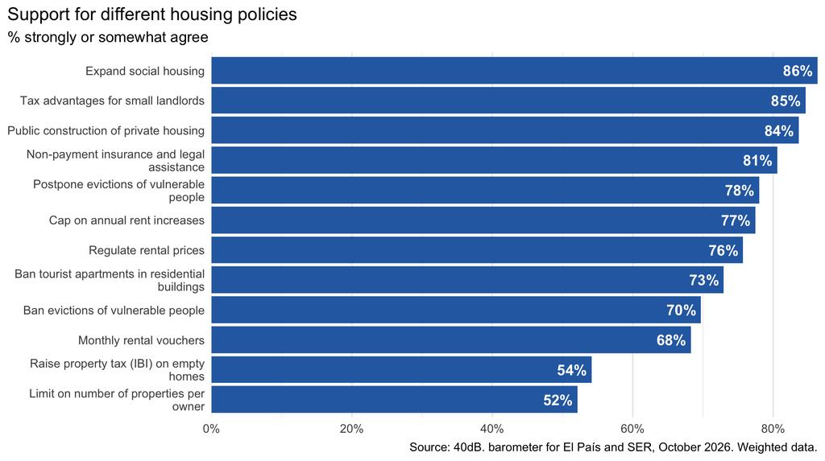

```r
ggplot(acuerdo, aes(x = pct, y = fct_reorder(str_wrap(politica, 38), pct))) +
  geom_col(fill = "#2b6cb0") +
  geom_text(aes(label = percent(pct, accuracy = 1)),
            hjust = 1.15, color = "white", fontface = "bold") +
  scale_x_continuous(labels = percent, expand = c(0, 0)) +
  labs(title = "Support for different housing policies",
       subtitle = "% strongly or somewhat agree",
       x = NULL, y = NULL,
       caption = "Source: 40dB. barometer for El País and SER, October 2026. Weighted data.") +
  theme_minimal(base_size = 13) +
  theme(panel.grid.major.y = element_blank(),
        plot.title.position = "plot")
```

## Common mistakes

| Symptom | Common cause | Solution |
| --- | --- | --- |
| `Error: unexpected symbol` | Missing a comma or parenthesis | Check the line R flags and the one before it |
| The graph comes out with no geometry (just axes) | You forgot the `geom_` | `ggplot(...) + geom_point()` |
| `+` at the **start** of a line | The `+` must go **at the end** of the previous line | `ggplot(...) +` and a line break |
| `object 'xxx' not found` | Misspelled name or variable that doesn’t exist | Check with `names(d)` |
| `Removed rows containing missing values` | There are `NA`s in one of the graph’s variables | It’s not an error. Check that these are the expected `NA`s |
| I mapped a color and got red with a weird legend | You put a fixed color **inside** `aes()` | `color = "red"` goes **outside** `aes()` |
| The x axis sorts `0, 1, 10, 2...` | The variable is text or a factor, not a number | Convert it with `as.numeric()` |
| The mean comes out `NA` | There are `NA`s in the data | `mean(x, na.rm = TRUE)` |
| `%>%` or `\|>` in the middle of the graph | You mixed pipe and `+` | Pipe to prepare data, `+` to add layers |
| The points overlap each other | 0 to 10 scales: many identical cases | `geom_jitter()` or low `alpha` |

**Descriptive statistics**

## The principle

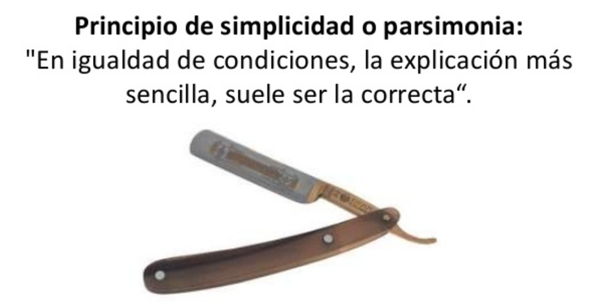

## Types of statistics: Descriptive

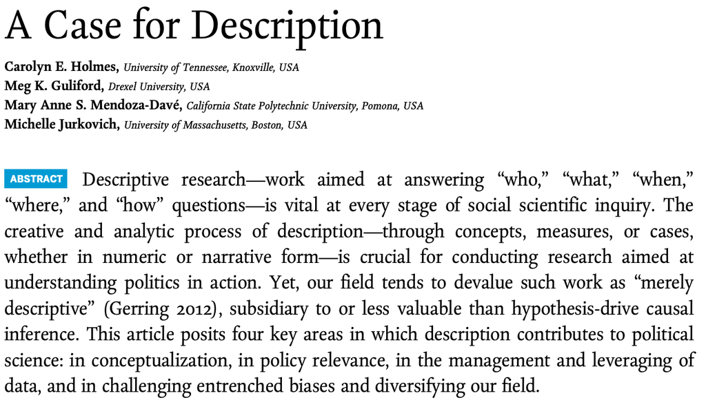

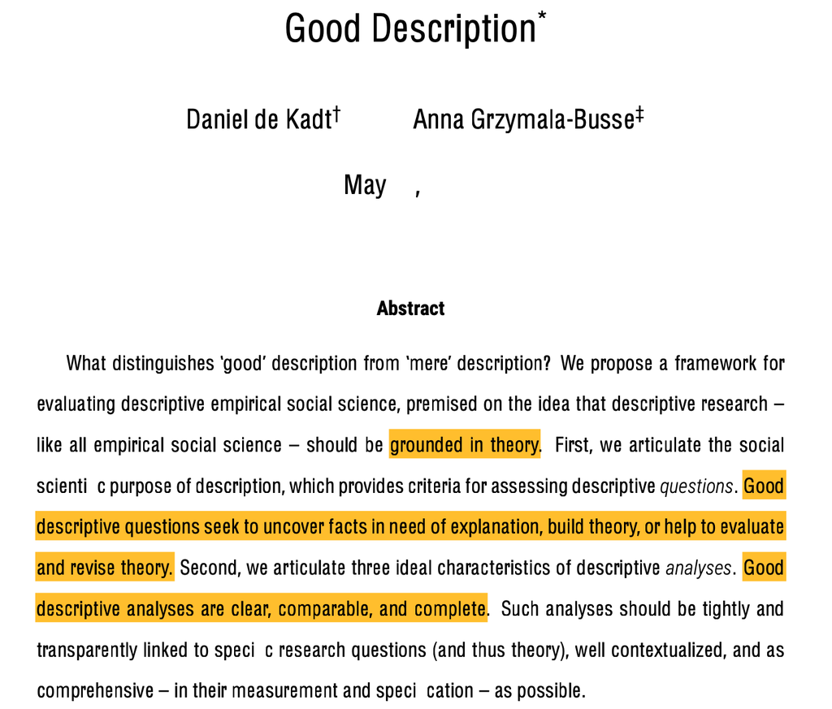

But, in descriptive statistics, generally, there is no uncertainty. The data is described as it’s collected.

**When and where do things get complicated?**

## The complexity of inference

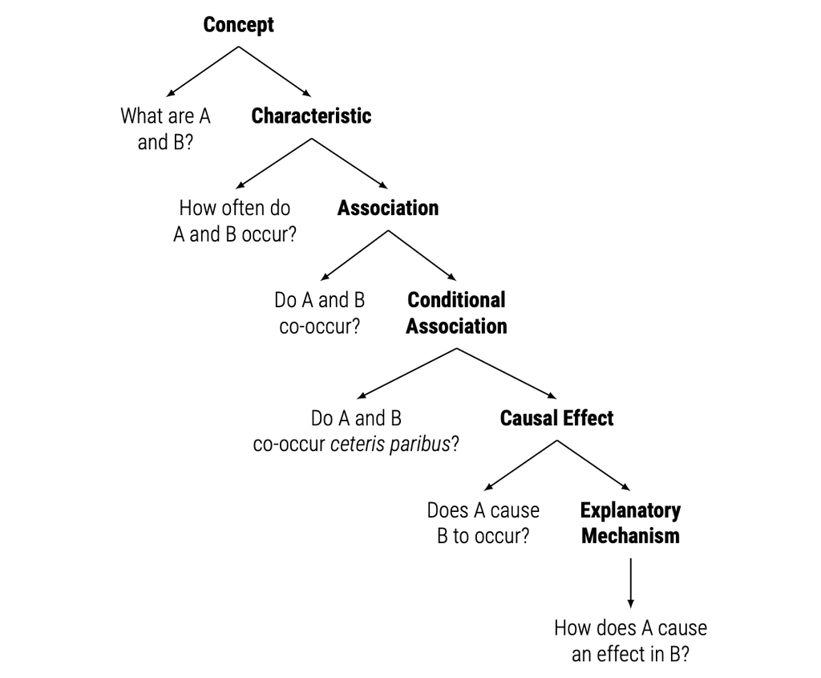

## Statistics, data, and inference

When we try to **EXTRAPOLATE** what we found in that *SAMPLE* to the *POPULATION*. I learn from the sample (I logistically cannot interview every person in a country) in order to learn about the population.

Our empirical analyses usually observe a sample of the observations:

- A political survey of a representative *SAMPLE*

To be able to extrapolate that result to the rest of the *target population*, we must assume several characteristics about our sample.

- Infer what? How true or likely it is that the result from our sample [t-test, cov, corr, regression] would be found in other samples from our population, and thus in our population

**Inferential stats**

## The p-value

1. Definition:
1. The probability of obtaining a statistic at least as extreme as the one observed if the null hypothesis were true
2. The probability that the relationship found is the product of chance or of our sample’s bias, and therefore not applicable to the population
2. It depends on:
- Larger effect size -> greater confidence that this relationship can be extrapolated from our sample to the population
- Larger n -> greater confidence that this relationship can be extrapolated from our sample to the population
3. Value between 0 and 1. The lower the p-value, the more certain the relationship between X and Y is in the sample
4. What is the p-value NOT?
- p=0.001 does not mean there’s a 0.999 probability that something systematic is happening
- it does **(NOT)** tell us about causality

## T-test: a reminder replicating Prillaman

- Let’s go back to the 40db data
- Question: *Do women and men differ in the ptv, campaign participation, and voting intentions?*
- Let’s look at the t-test formula:

$T = \frac{x_a - x_b}{\sqrt{\frac{(s_a)^2}{n_a} + \frac{(s_b)^2}{n_b}}}$

- Clean the code an apply it:

```r
library(tidyverse)
library(broom)
library(haven)
library(patchwork)

datos <- read_dta("03_Datos_octubre_2026.dta", encoding = "latin1") |>
  zap_labels()

# Variables construidas a partir del cuestionario (valores altos = más de cada cosa)
datos <- datos |>
  mutate(
    # P2 probabilidad de votar (0 a 10, 99 = NS/NC)
    turnout      = if_else(p2 == 99, NA_real_, p2),
    # P5 probabilidad de votar a cada partido (0 a 10, 99 = NS)
    across(p5_1:p5_6, ~ if_else(.x == 99, NA_real_, .x), .names = "ptv_{.col}"),
    # P7 ubicación ideológica (0 izquierda, 10 derecha)
    ideologia    = if_else(p7 == 99, NA_real_, p7),
    # P8_1 preocupación por el coste de la vivienda (1 mucho a 4 nada, 5 = NS)
    preocup_viv  = if_else(p8_1 == 5, NA_real_, 5 - p8_1),
    # P12 interés por el caso Maricarmen (0 no lo conocía a 3 mucho interés)
    interes_caso = 4 - p12,
    # P14 acuerdo con interrumpir desahucios de forma pacífica (1 a 4)
    resist_pac   = if_else(p14 == 5, NA_real_, 5 - p14),
    # P15 protesta por la vivienda en el último año (1 = sí, 4 = prefiere no contestar)
    protesta     = case_when(p15 == 1 ~ 1, p15 %in% 2:3 ~ 0, TRUE ~ NA_real_),
    # P36 miedo a dejar la vivienda por motivos económicos (1 a 4, 5 = NS)
    miedo_dejar  = if_else(p36 == 5, NA_real_, 5 - p36)
  )

vars <- c(turnout      = "Turnout intention",
          ptv_p5_1     = "PTV PSOE",
          ptv_p5_2     = "PTV PP",
          ptv_p5_3     = "PTV Vox",
          ptv_p5_4     = "PTV Sumar",
          ptv_p5_5     = "PTV Podemos",
          ptv_p5_6     = "PTV Se Acabó la Fiesta",
          ideologia    = "Left-right (right = high)",
          preocup_viv  = "Worry about housing costs",
          interes_caso = "Interest in Maricarmen case",
          resist_pac   = "Support peaceful resistance to evictions",
          protesta     = "Joined housing protest",
          miedo_dejar  = "Fear of losing current home")

# Sexo: se asume una variable "sexo" con 1 = hombre y 2 = mujer (comprobar con names(datos))
long <- datos |>
  mutate(genero = factor(sexo, levels = c(1, 2), labels = c("Men", "Women")),
         across(all_of(names(vars)), ~ as.numeric(scale(.x)))) |>
  filter(!is.na(genero)) |>
  select(genero, all_of(names(vars))) |>
  pivot_longer(-genero, names_to = "item", values_to = "z")

# t-test por dimensión (estimate = hombres menos mujeres)
res <- long |>
  group_by(item) |>
  group_modify(~ tidy(t.test(z ~ genero, data = .x))) |>
  ungroup() |>
  mutate(dimension = fct_reorder(vars[item], estimate))

res |> select(dimension, estimate, statistic, p.value, conf.low, conf.high)
```

```
# A tibble: 13 × 6
   dimension                       estimate statistic p.value conf.low conf.high
   <fct>                              <dbl>     <dbl>   <dbl>    <dbl>     <dbl>
 1 Left-right (right = high)        0.0678     1.46   1.45e-1 -0.0235     0.159
 2 Interest in Maricarmen case     -0.0381    -0.851  3.95e-1 -0.126      0.0496
 3 Fear of losing current home     -0.233     -5.14   2.97e-7 -0.322     -0.144
 4 Worry about housing costs       -0.105     -2.32   2.07e-2 -0.193     -0.0160
 5 Joined housing protest           0.0870     1.89   5.87e-2 -0.00319    0.177
 6 PTV PSOE                        -0.117     -2.57   1.01e-2 -0.206     -0.0279
 7 PTV PP                          -0.0147    -0.322  7.48e-1 -0.104      0.0749
 8 PTV Vox                          0.132      2.90   3.77e-3  0.0427     0.221
 9 PTV Sumar                       -0.00497   -0.109  9.13e-1 -0.0947     0.0848
10 PTV Podemos                     -0.00297   -0.0651 9.48e-1 -0.0925     0.0866
11 PTV Se Acabó la Fiesta           0.106      2.31   2.08e-2  0.0162     0.196
12 Support peaceful resistance to… -0.279     -6.12   1.14e-9 -0.369     -0.190
13 Turnout intention                0.0407     0.897  3.70e-1 -0.0482     0.130
```

## Replicating Prillaman (II)

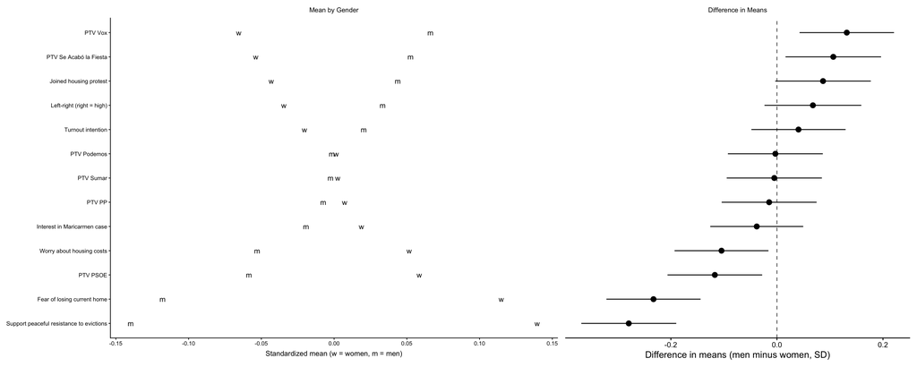

**Covariance and correlation**

## Summarizing the relationship between two variables

Ideology and concern for AI. *How would you investigate this association?*

1. **Compare the means** of one variable (y) across the values of the other (x)–imagine we have these variables in our sample
2. Show the **covariance/correlation**
3. Show the **regression coefficients**
4. Add control variables (against omitted variable bias)
5. Design an experiment

## Comparing means

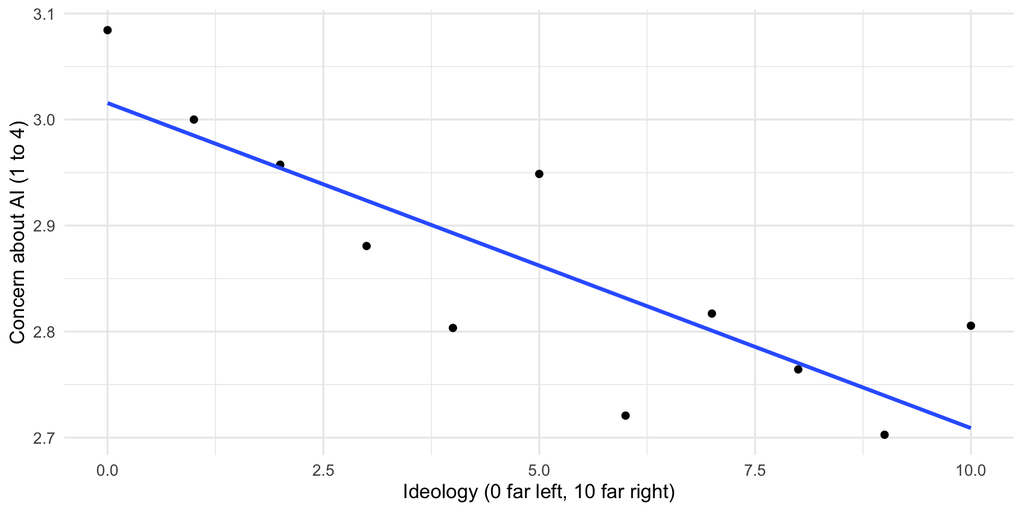

```r
datos |>
  zap_labels() |>
  select(ideologia = p7, ia = p8_8) |>
  mutate(
    ideologia = if_else(ideologia == 99, NA_real_, ideologia),  # 99 is Don't know
    # 5 is Don't know. We reverse the scale so higher means more concern (1 to 4)
    ia = if_else(ia == 5, NA_real_, 5 - ia)
  ) |>
  drop_na() |>
  group_by(ideologia) |>
  summarise(ia_mean = mean(ia), .groups = "drop") |>
  ggplot(aes(x = ideologia, y = ia_mean)) +
  geom_point() +
  geom_smooth(method = "lm", se = F) +
  labs(x = "Ideology (0 far left, 10 far right)", y = "Concern about AI (1 to 4)") +
  theme_minimal(base_size = 14)
```

## Comparing means -> Comparing variances

- We’re changing examples (momentarily): now we’ll talk about the association between education and concern about AI
- Let’s take a step back and return to the variance of each variable

Variance: a measure of the **dispersion** of a single variable

$Var(x)=\frac{\sum{(x_i-\bar{x})^2}}{n-1}$

- Made-up data on education (years of study) and concern about AI (1 to 4, higher is more concerned) with 4 observations (not enough, I know, but it’s to explain how we calculate the parameter of interest)

```r
library(tidyverse)

ejemplo <- tibble(
  persona = c("A", "B", "C", "D"),
  educacion = c(8, 10, 14, 16),
  ia = c(4, 3, 3, 2)
)

ejemplo
```

```
# A tibble: 4 × 3
  persona educacion    ia
  <chr>       <dbl> <dbl>
1 A               8     4
2 B              10     3
3 C              14     3
4 D              16     2
```

## First, look at the data

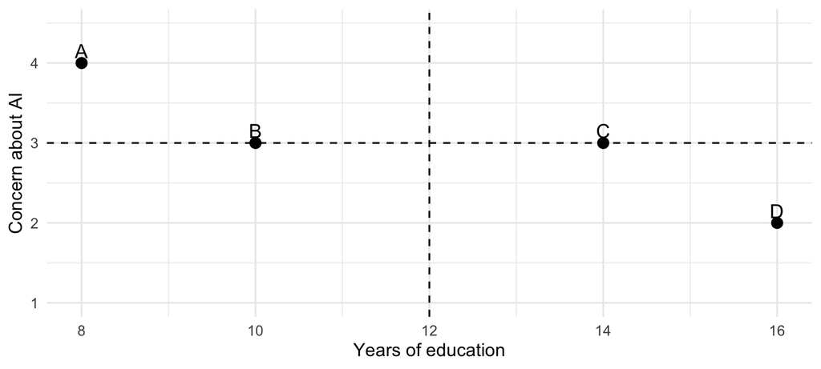

```r
ggplot(ejemplo, aes(educacion, ia, label = persona)) +
  geom_vline(xintercept = mean(ejemplo$educacion), linetype = "dashed") +
  geom_hline(yintercept = mean(ejemplo$ia), linetype = "dashed") +
  geom_point(size = 4) +
  geom_text(nudge_y = 0.15, size = 6) +
  scale_y_continuous(limits = c(1, 4.5)) +
  labs(x = "Years of education", y = "Concern about AI") +
  theme_minimal(base_size = 16)
```

## Step 1, deviations from the mean

```r
ejemplo <- ejemplo |>
  mutate(
    dx = educacion - mean(educacion),
    dy = ia - mean(ia),
    dx2 = dx^2,
    dy2 = dy^2,
    dxdy = dx * dy
  )

ejemplo
```

```
# A tibble: 4 × 8
  persona educacion    ia    dx    dy   dx2   dy2  dxdy
  <chr>       <dbl> <dbl> <dbl> <dbl> <dbl> <dbl> <dbl>
1 A               8     4    -4     1    16     1    -4
2 B              10     3    -2     0     4     0     0
3 C              14     3     2     0     4     0     0
4 D              16     2     4    -1    16     1    -4
```

- `dx2` and `dy2` feed the **variance**
- `dxdy` feeds the **covariance**. It’s positive if the two points are on the same side of their means and negative if they’re on opposite sides

## Step 2, variance and covariance by hand

```r
n <- nrow(ejemplo)

var_x  <- sum(ejemplo$dx2) / (n - 1)    # 40 / 3
var_y  <- sum(ejemplo$dy2) / (n - 1)    # 2 / 3
cov_xy <- sum(ejemplo$dxdy) / (n - 1)   # -8 / 3

c(var_x = var_x, var_y = var_y, cov_xy = cov_xy)
```

```
     var_x      var_y     cov_xy
13.3333333  0.6666667 -2.6666667
```

$Cov(education, AI) = -2{,}67$ indicates that more education is associated with less concern about AI. But that −2.67 doesn’t tell us whether the association is strong or weak (in months it would be −32)

**What it tells us.** The *direction* of the linear association between two variables

- $Cov > 0$ when one variable is above its mean, the other tends to be too
- $Cov < 0$ when one is above its mean, the other tends to be below
- $Cov \approx 0$ there’s no linear association

**How it’s interpreted:** We’ll focus on the **direction (pos, neg)**, not the magnitude (it depends on the units, so it’s not comparable across pairs of variables)

## Step 3, correlation by hand

$Cor(x,y) = \frac{Cov(x,y)}{sd(x)sd(y)}$ can also be written as $r(x,y)$

It tells us the *direction* and the *strength* of the **linear** association

- The **sign** indicates the direction, same as with covariance
- The **absolute value** indicates the strength, from 0 (none) to 1 (perfect line)

It’s useful for comparing associations between variables measured on different scales

**Rough rules of thumb** (depend on the discipline)

| $\lvert r \rvert$ | Reading |
| --- | --- |
| 0.1 | weak |
| 0.3 | moderate |
| 0.5 or more | strong |

```r
cor_xy <- cov_xy / (sqrt(var_x) * sqrt(var_y))
cor_xy
```

```
[1] -0.8944272
```

Let’s check with `R`’s functions

```r
c(var(ejemplo$educacion), var(ejemplo$ia), cov(ejemplo$educacion, ejemplo$ia), cor(ejemplo$educacion, ejemplo$ia))
```

```
[1] 13.3333333  0.6666667 -2.6666667 -0.8944272
```

$r = -0{,}89$ is a strong, negative association.

**$r^2$** is the proportion of variance shared by the two variables

And $r^2 = 0{,}80$, meaning education “explains” 80% of the variance in concern about AI in these 4 cases

**A problem?**

- Correlation tells us about the direction (neg, pos), and the linearity (robustness) of the association, but it doesn’t give us a clear interpretation of the association—**regression will help us with that**

**Regression, at last**

## Regression

[figure not shown]

## The logic of regression

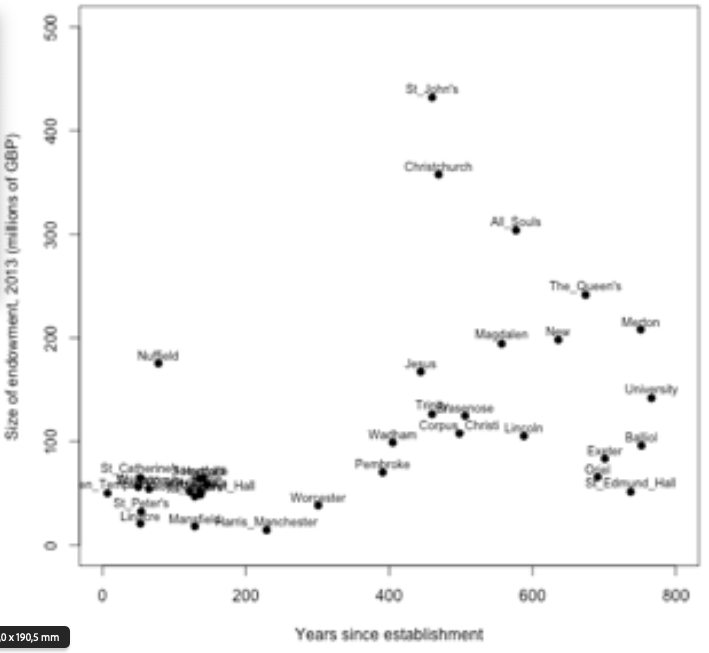

The goal is to **summarize** the relationship between both variables

How do we identify the line that best summarizes the association between the two variables?

**Linear regression** (OLS, ordinary least squares) is the one that minimizes the squared distance of the points to the line

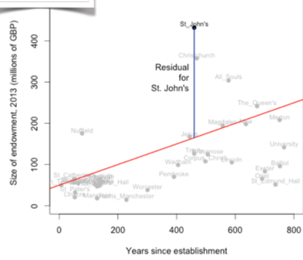

## Bivariate regression, components

$y_i = a + \beta x_i + u_i$

What do we mean by minimizing the error?

$\min \sum \hat{u_i}^2$

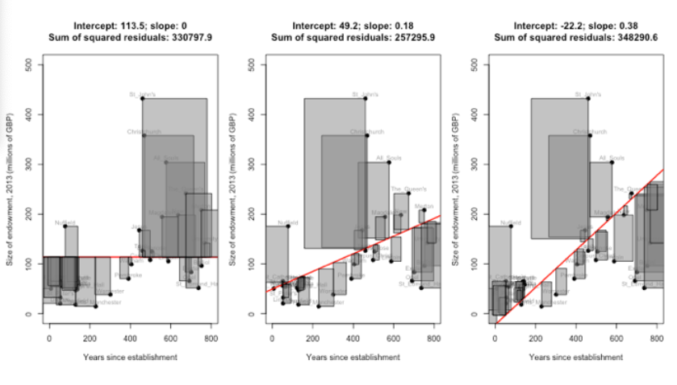

Two components

- $\hat{\alpha}$: intercept, the starting point of the line on the y axis when x = 0
- $\hat{\beta} = \frac{Cov(x,y)}{Var(x)}$: the slope of the line

## Properties of regression

The sign of the covariance, the correlation, and the regression’s $\hat{\beta}$ is the same

- Let’s go back to the 40db data and the example between ideology and concern about AI

```r
ia_ideologia <- datos |>
  zap_labels() |>
  select(ideologia = p7, ia = p8_8) |>
  mutate(
    ideologia = if_else(ideologia == 99, NA_real_, ideologia),  # 99 is Don't know
    # 5 is Don't know. We reverse the scale so higher means more concern (1 to 4)
    ia = if_else(ia == 5, NA_real_, 5 - ia)
  ) |>
  drop_na()

cov(ia_ideologia$ideologia, ia_ideologia$ia)
```

```
[1] -0.1907889
```

```r
cor(ia_ideologia$ideologia, ia_ideologia$ia)
```

```
[1] -0.08161156
```

```r
summary(lm(ia_ideologia$ideologia ~ ia_ideologia$ia))
```

```
Call:
lm(formula = ia_ideologia$ideologia ~ ia_ideologia$ia)

Residuals:
    Min      1Q  Median      3Q     Max
-5.3574 -1.8902  0.1098  1.8762  5.3434

Coefficients:
                Estimate Std. Error t value Pr(>|t|)
(Intercept)      5.59103    0.20152  27.744  < 2e-16 ***
ia_ideologia$ia -0.23362    0.06695  -3.489 0.000496 ***
---
Signif. codes:  0 '***' 0.001 '**' 0.01 '*' 0.05 '.' 0.1 ' ' 1

Residual standard error: 2.579 on 1816 degrees of freedom
Multiple R-squared:  0.00666,   Adjusted R-squared:  0.006113
F-statistic: 12.18 on 1 and 1816 DF,  p-value: 0.0004955
```

What does correlation tell us? How linear the relationship is

What does the regression’s beta tell us? **The slope of the regression line**, how much Y moves (concern about AI, from 1 to 4), according to the regression line, when we move one unit to the right (+1) in ideological self-placement

**Interpretation**: one point further to the right makes people, on average, worry 0.03 points less about AI (on a 1 to 4 scale)

## Interpreting and predicting

Let’s use the components and the estimate to *predict* the worrisome of a person in a 3 and a 6 of the ideological scale:

$\hat{y} = \hat{\alpha} + \hat{\beta}x$

$\hat{y} = 3.01 + -0.028\times3$

$\hat{y} = 3.01 + -0.028\times6$

**What else do we get from a regression?**

```r
modelo_ia_ideo <- lm(ia ~ ideologia, data = ia_ideologia)
summary(modelo_ia_ideo)
```

```
Call:
lm(formula = ia ~ ideologia, data = ia_ideologia)

Residuals:
    Min      1Q  Median      3Q     Max
-2.0116 -0.8405  0.1025  1.0455  1.2735

Coefficients:
            Estimate Std. Error t value Pr(>|t|)
(Intercept)  3.01156    0.04541  66.313  < 2e-16 ***
ideologia   -0.02851    0.00817  -3.489 0.000496 ***
---
Signif. codes:  0 '***' 0.001 '**' 0.01 '*' 0.05 '.' 0.1 ' ' 1

Residual standard error: 0.9009 on 1816 degrees of freedom
Multiple R-squared:  0.00666,   Adjusted R-squared:  0.006113
F-statistic: 12.18 on 1 and 1816 DF,  p-value: 0.0004955
```

## The p-value and the R² of the regression

**Question**: how do we get the p-value to test our hypothesis?

1. We obtain the t-statistic, $t = \frac{\beta-0}{se(\beta)}$
2. We look up the t value, taking into account the degrees of freedom, in our beloved table

This relationship seems so robust that, given that this sample was drawn at random, we can extrapolate it to the population

## Regression assumptions

- Validity of the data for answering the research question
- Linearity of the relationship between the outcome and the predictor variables [scatterplot y~x]
- Equal variance of the errors, homoscedasticity

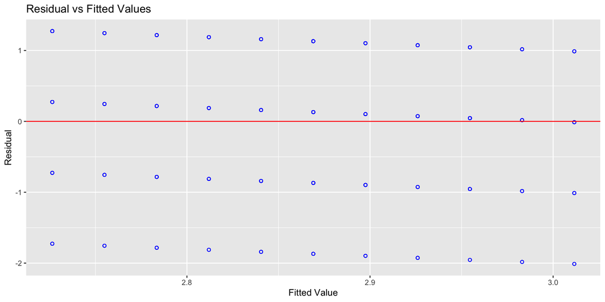

```r
olsrr::ols_plot_resid_fit(modelo_ia_ideo)
```

- Normality of the errors

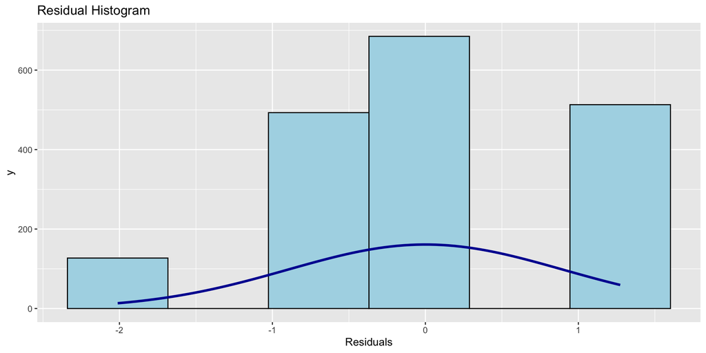

```r
olsrr::ols_plot_resid_hist(modelo_ia_ideo)
```

## Is this causal?

[figure not shown]

[figure not shown]

[figure not shown]

## Causality, omitted variable bias

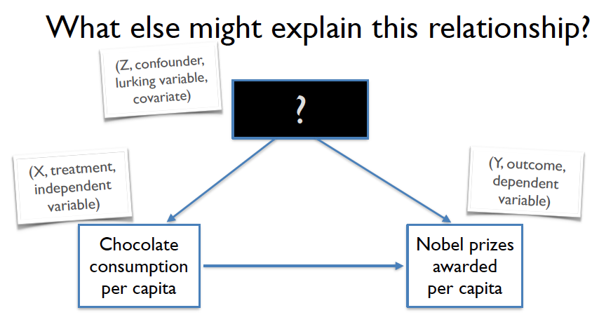

- Is this a *spurious* correlation?
- How do we find the *Z*s? Which ones do you see here?
- How do we reduce **omitted variable bias**?

## The experimental ideal

- Ideally we’d have a randomly assigned treatment, so we could understand that our regression’s result captures the causal effect of X on Y
- Randomized experiments are unlikely in many fields of social science

**The next step**: controlling to “*balance*”

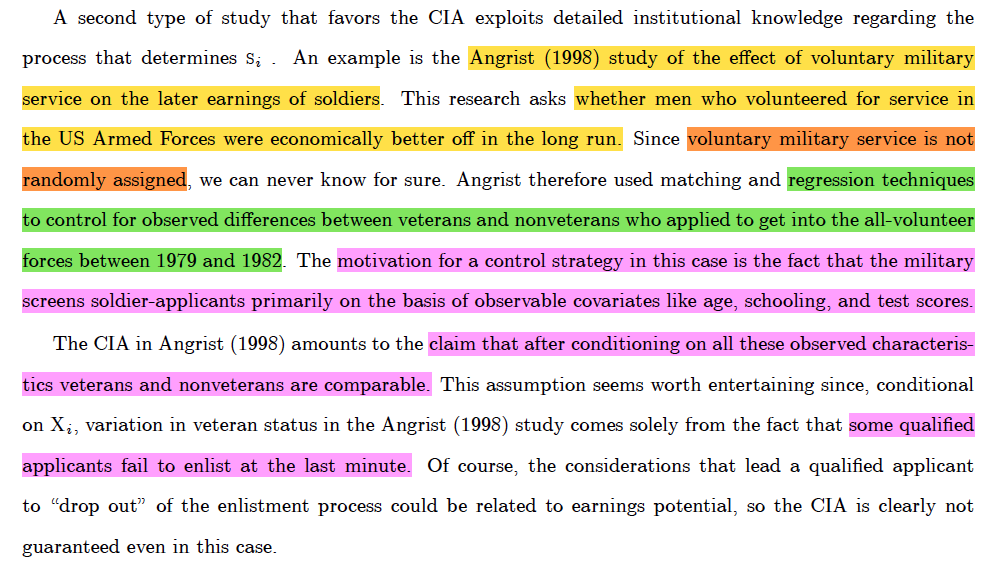

Source: Mostly Harmless Econometrics, p. 47

## Controlling like Boix and Stokes

Boix and Stokes vs. Przeworski

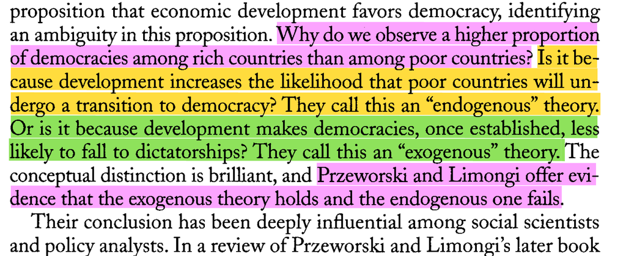

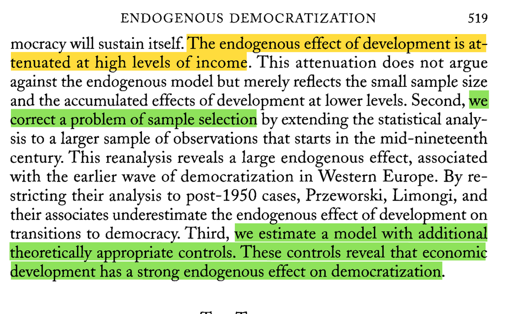

[figure not shown]

## Wrapping up

- The CLT tells us why a random sample lets us learn about the population, with an uncertainty we can measure with the SE and the CI
- The p-value accompanies almost all of our tools, Chi2 for two categorical variables, the t-test for one continuous and one categorical
- Covariance gives us the direction of a relationship, correlation standardizes it and tells us how linear it is
- Regression summarizes that relationship into an interpretable slope, but it’s only causal if we’ve properly controlled for what confounds X and Y
- Next week we’ll keep controlling

## Questions?

```css
.center h2 {
  text-align: center;
}
```

You can also reach me here: smsoler@clio.uc3m.es

Research Seminar